# PEC 3

** Hipótesis de 2 modelos**

¿Depende la resistencia a la insulina de ser obeso? y de ser diabético tipo 2?

Uilizaremos HOMA_IR como predictor, para ver si existen diferencias en función de ser o no diabético, y de ser obeso o no.

[figure not shown]

```r
par(mfrow=c(1,2))
boxplot(HOMA_IR~ DM_status, data=datosdf2, col=c(3,2))
boxplot(HOMA_IR~BMI_group, data = datosdf2, col=c(3,2))
```

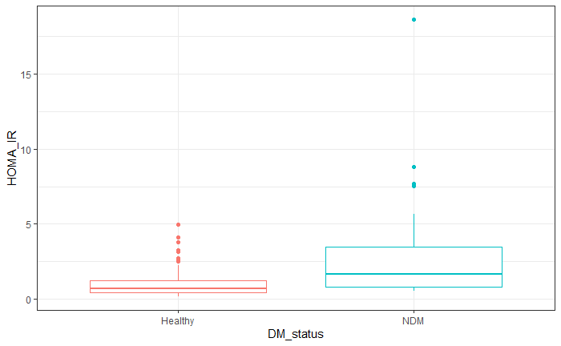

```r
ggplot(data = datosdf2) +
  geom_boxplot(aes(x = DM_status, y = HOMA_IR, colour = DM_status)) +
  theme_bw() + theme(legend.position = "none")
```

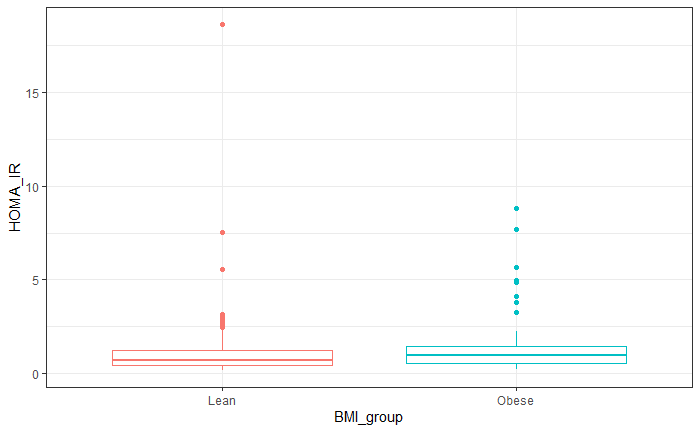

```r
ggplot(data = datosdf2) +
  geom_boxplot(aes(x = BMI_group, y = HOMA_IR, colour = BMI_group)) +
  theme_bw() + theme(legend.position = "none")
```

```r
NA
NA
```

**Test de Fisher.** Para saber si existe relación entre dos variables categóricas, podemos hacer un test de Fisher a partir de una tabla de contingencia:

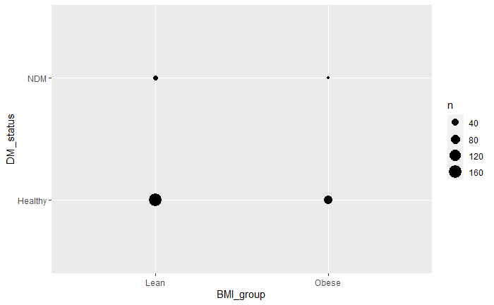

```r
tabla <- table(datosdf2$BMI_group, datosdf2$DM_status, dnn = c("obeso o no", "diabético o no"))
ggplot(data = datosdf2) +
  geom_count(mapping = aes(x = BMI_group, y = DM_status))
```

Ho : Las variables son independientes por lo que una variable no varía entre los distintos niveles de la otra variable. Ha: Las variables son dependientes, una variable varía entre los distintos niveles de la otra variable.

```r
fisher.test(x = tabla, alternative = "two.sided")
```

```
    Fisher's Exact Test for Count Data

data:  tabla
p-value = 0.5094
alternative hypothesis: true odds ratio is not equal to 1
95 percent confidence interval:
 0.4903449 3.2198846
sample estimates:
odds ratio
  1.301234
```

No podríamos rechazar la hipótesis nula (alpha=0.05). Dado que el test de Fisher contrasta si las variables están relacionadas, al tamaño del efecto se le conoce como fuerza de asociación. Existen múltiples medidas de asociación, entre las que destacan phi o Cramer’s V. Los límites empleados para su clasificación son: pequeño: 0.1 mediano: 0.3 grande: 0.5 En R se pueden calcular mediante la función assocstats() del paquete vcd.

```r
library(grid)
library(vcd)
assocstats(x = tabla)
```

```
                     X^2 df P(> X^2)
Likelihood Ratio 0.36547  1  0.54548
Pearson          0.37649  1  0.53949

Phi-Coefficient   : 0.039
Contingency Coeff.: 0.039
Cramer's V        : 0.039
```

**χ2 de Pearson (test de independencia)**

Es el test aproximado equivalente a su versión exacta test de Fisher. Debido a los requerimientos de cálculo del test de Fisher, cuando hay muchas observaciones o muchos niveles, se emplea el test χ2 de independencia. La distribución chi-cuadrado es siempre positiva, por lo que para calcular el p-value solo se tiene en cuenta la cola superior.

```r
chisq.test(x = tabla)
```

```
    Pearson's Chi-squared test with Yates' continuity correction

data:  tabla
X-squared = 0.15101, df = 1, p-value = 0.6976
```

Solución mediante simulación:

```r
chisq.test(tabla, simulate.p.value = TRUE, B = 5000)
```

```
    Pearson's Chi-squared test with simulated p-value (based on 5000 replicates)

data:  tabla
X-squared = 0.37649, df = NA, p-value = 0.6501
```

**Anova.**

Contrastamos si la resistencia a la insulina es igual en diabético y no diabéticos, y en obesos o no:

```r
anova(lm(HOMA_IR~DM_status, data = datosdf2))
```

```
Analysis of Variance Table

Response: HOMA_IR
           Df Sum Sq Mean Sq F value    Pr(>F)
DM_status   1 124.94  124.94  60.641 1.802e-13 ***
Residuals 251 517.12    2.06
---
Signif. codes:  0 ‘***’ 0.001 ‘**’ 0.01 ‘*’ 0.05 ‘.’ 0.1 ‘ ’ 1
```

```r
anova(lm(HOMA_IR~BMI_group, data = datosdf2))
```

```
Analysis of Variance Table

Response: HOMA_IR
           Df Sum Sq Mean Sq F value Pr(>F)
BMI_group   1   6.87  6.8668  2.7134 0.1008
Residuals 251 635.19  2.5307
```

Los valores de HOMA_IR dependen de la condición de estar o no enfermo, pero no del IMC (nivel de significación 0.05)

Se podría estudiar también como influyen las variables en la resistencia a la insulina, pero específicamente en individuos diabéticos y/o sanos independientemente, de esta manera obtenemos valores de t para cada grupo

```r
datHealth<- subset(datosdf2, datosdf2$DM_status=="Healthy")
datDM <- subset(datosdf2, datosdf2$DM_status=="NDM")
lmH<- lm(HOMA_IR~ BMI + WC + TG+ TC+ FBS..mmol.l.+SBP+DBP+ F.Ins.pmol.L.+HOMA_B+ Adiponectin.microgm.ml...5000.X. +Leptin..ng.ml.,data = datHealth)
lmDM<-lm(HOMA_IR~ BMI + WC + TG+ TC+ FBS..mmol.l.+SBP+DBP+ F.Ins.pmol.L.+HOMA_B+ Adiponectin.microgm.ml...5000.X. +Leptin..ng.ml., data = datDM)
summary(lmH);summary(lmDM)
```

```
Call:
lm(formula = HOMA_IR ~ BMI + WC + TG + TC + FBS..mmol.l. + SBP +
    DBP + F.Ins.pmol.L. + HOMA_B + Adiponectin.microgm.ml...5000.X. +
    Leptin..ng.ml., data = datHealth)

Residuals:
     Min       1Q   Median       3Q      Max
-0.12364 -0.03763 -0.01393  0.02436  0.42159

Coefficients:
                                   Estimate Std. Error t value Pr(>|t|)
(Intercept)                      -4.669e-01  7.796e-02  -5.990 8.85e-09 ***
BMI                               3.070e-03  2.155e-03   1.425 0.155748
WC                                5.676e-04  7.773e-04   0.730 0.466052
TG                               -6.003e-06  6.018e-05  -0.100 0.920630
TC                               -1.686e-04  1.362e-04  -1.238 0.217181
FBS..mmol.l.                      8.222e-02  1.519e-02   5.413 1.66e-07 ***
SBP                               1.709e-04  2.769e-04   0.617 0.537738
DBP                              -2.520e-04  4.877e-04  -0.517 0.605953
F.Ins.pmol.L.                     3.597e-02  4.968e-04  72.402  < 2e-16 ***
HOMA_B                           -1.707e-03  2.010e-04  -8.492 3.49e-15 ***
Adiponectin.microgm.ml...5000.X. -8.638e-04  1.673e-03  -0.516 0.606255
Leptin..ng.ml.                   -6.762e-04  1.908e-04  -3.543 0.000486 ***
---
Signif. codes:  0 ‘***’ 0.001 ‘**’ 0.01 ‘*’ 0.05 ‘.’ 0.1 ‘ ’ 1

Residual standard error: 0.0693 on 213 degrees of freedom
Multiple R-squared:  0.9909,    Adjusted R-squared:  0.9904
F-statistic:  2103 on 11 and 213 DF,  p-value: < 2.2e-16


Call:
lm(formula = HOMA_IR ~ BMI + WC + TG + TC + FBS..mmol.l. + SBP +
    DBP + F.Ins.pmol.L. + HOMA_B + Adiponectin.microgm.ml...5000.X. +
    Leptin..ng.ml., data = datDM)

Residuals:
     Min       1Q   Median       3Q      Max
-1.32848 -0.31294 -0.01563  0.23274  1.47021

Coefficients:
                                  Estimate Std. Error t value Pr(>|t|)
(Intercept)                       0.284059   2.889828   0.098 0.922918
BMI                               0.004469   0.106880   0.042 0.967167
WC                               -0.015137   0.038515  -0.393 0.699501
TG                               -0.000643   0.001731  -0.371 0.715220
TC                               -0.003825   0.004328  -0.884 0.389879
FBS..mmol.l.                      0.114273   0.076129   1.501 0.152818
SBP                               0.004334   0.012629   0.343 0.735925
DBP                               0.004344   0.023272   0.187 0.854280
F.Ins.pmol.L.                     0.128317   0.011106  11.553 3.56e-09 ***
HOMA_B                           -0.101566   0.021683  -4.684 0.000249 ***
Adiponectin.microgm.ml...5000.X. -0.125664   0.071720  -1.752 0.098890 .
Leptin..ng.ml.                   -0.004500   0.004913  -0.916 0.373319
---
Signif. codes:  0 ‘***’ 0.001 ‘**’ 0.01 ‘*’ 0.05 ‘.’ 0.1 ‘ ’ 1

Residual standard error: 0.7674 on 16 degrees of freedom
Multiple R-squared:  0.9767,    Adjusted R-squared:  0.9607
F-statistic: 61.07 on 11 and 16 DF,  p-value: 6.326e-11
```

Por los valores de R-squared, estos modelos explicarían un alto porcentaje de la variabilidad. Observamos que los niveles de leptina son más significativos en el caso de los individuos sanos, en cambio en el caso de los diabéticos es más significativa la adiponectina. Además, vemos que los niveles de azúcar en ayunas, aunque explican algo de variabilidad, no son tan significantes en el caso de los diabéticos, pero sí en el grupo de individuos sanos.

Por lo tanto, estos modelos también se pueden simplificar usando las variables con nivel de significación más alto:

```r
lmH2<- lm(HOMA_IR~ FBS..mmol.l.+ F.Ins.pmol.L.+HOMA_B+ Leptin..ng.ml.,data = datHealth)
lmDM2<-lm(HOMA_IR~ F.Ins.pmol.L.+HOMA_B+ Adiponectin.microgm.ml...5000.X., data = datDM)
anova(lmH, lmH2)
```

```
Analysis of Variance Table

Model 1: HOMA_IR ~ BMI + WC + TG + TC + FBS..mmol.l. + SBP + DBP + F.Ins.pmol.L. +
    HOMA_B + Adiponectin.microgm.ml...5000.X. + Leptin..ng.ml.
Model 2: HOMA_IR ~ FBS..mmol.l. + F.Ins.pmol.L. + HOMA_B + Leptin..ng.ml.
  Res.Df    RSS Df Sum of Sq      F Pr(>F)
1    213 1.0229
2    220 1.0813 -7 -0.058344 1.7355 0.1021
```

```r
anova(lmDM, lmDM2)
```

```
Analysis of Variance Table

Model 1: HOMA_IR ~ BMI + WC + TG + TC + FBS..mmol.l. + SBP + DBP + F.Ins.pmol.L. +
    HOMA_B + Adiponectin.microgm.ml...5000.X. + Leptin..ng.ml.
Model 2: HOMA_IR ~ F.Ins.pmol.L. + HOMA_B + Adiponectin.microgm.ml...5000.X.
  Res.Df     RSS Df Sum of Sq      F Pr(>F)
1     16  9.4218
2     24 13.5518 -8     -4.13 0.8767 0.5556
```

```r
summary(lmH2); summary(lmDM2)
```

```
Call:
lm(formula = HOMA_IR ~ FBS..mmol.l. + F.Ins.pmol.L. + HOMA_B +
    Leptin..ng.ml., data = datHealth)

Residuals:
     Min       1Q   Median       3Q      Max
-0.13823 -0.03795 -0.01779  0.02225  0.46136

Coefficients:
                 Estimate Std. Error t value Pr(>|t|)
(Intercept)    -0.4138757  0.0731701  -5.656 4.78e-08 ***
FBS..mmol.l.    0.0874155  0.0149846   5.834 1.92e-08 ***
F.Ins.pmol.L.   0.0359473  0.0004971  72.309  < 2e-16 ***
HOMA_B         -0.0016673  0.0002015  -8.274 1.24e-14 ***
Leptin..ng.ml. -0.0004826  0.0001765  -2.734  0.00676 **
---
Signif. codes:  0 ‘***’ 0.001 ‘**’ 0.01 ‘*’ 0.05 ‘.’ 0.1 ‘ ’ 1

Residual standard error: 0.07011 on 220 degrees of freedom
Multiple R-squared:  0.9904,    Adjusted R-squared:  0.9902
F-statistic:  5647 on 4 and 220 DF,  p-value: < 2.2e-16


Call:
lm(formula = HOMA_IR ~ F.Ins.pmol.L. + HOMA_B + Adiponectin.microgm.ml...5000.X.,
    data = datDM)

Residuals:
     Min       1Q   Median       3Q      Max
-1.83962 -0.24976 -0.05204  0.20139  1.98300

Coefficients:
                                  Estimate Std. Error t value Pr(>|t|)
(Intercept)                       0.475716   0.322216   1.476   0.1528
F.Ins.pmol.L.                     0.141150   0.005924  23.825  < 2e-16 ***
HOMA_B                           -0.133652   0.011094 -12.048 1.15e-11 ***
Adiponectin.microgm.ml...5000.X. -0.140563   0.052157  -2.695   0.0127 *
---
Signif. codes:  0 ‘***’ 0.001 ‘**’ 0.01 ‘*’ 0.05 ‘.’ 0.1 ‘ ’ 1

Residual standard error: 0.7514 on 24 degrees of freedom
Multiple R-squared:  0.9665,    Adjusted R-squared:  0.9624
F-statistic: 231.1 on 3 and 24 DF,  p-value: < 2.2e-16
```

```r
confint(lmH2); confint(lmDM2)
```

```
                       2.5 %        97.5 %
(Intercept)    -0.5580797814 -0.2696716455
FBS..mmol.l.    0.0578837389  0.1169473139
F.Ins.pmol.L.   0.0349675690  0.0369270936
HOMA_B         -0.0020644454 -0.0012701589
Leptin..ng.ml. -0.0008305017 -0.0001347466
                                      2.5 %      97.5 %
(Intercept)                      -0.1893050  1.14073639
F.Ins.pmol.L.                     0.1289222  0.15337714
HOMA_B                           -0.1565487 -0.11075586
Adiponectin.microgm.ml...5000.X. -0.2482102 -0.03291514
```

De nuevo, nos quedaríamos con el modelo más simple (en ambos grupos).

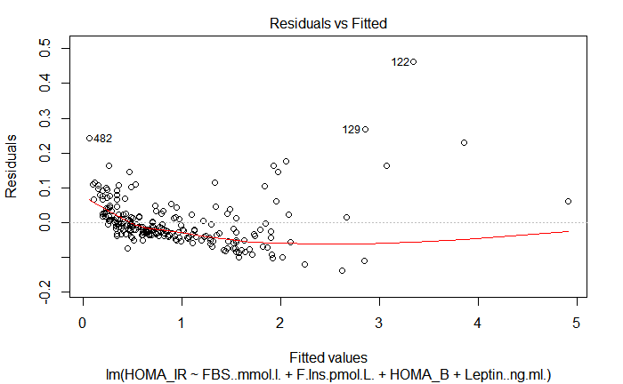

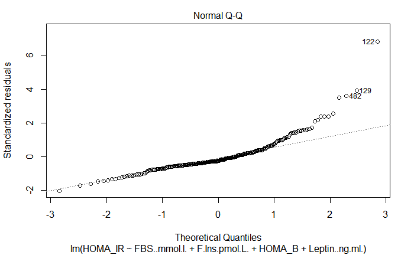

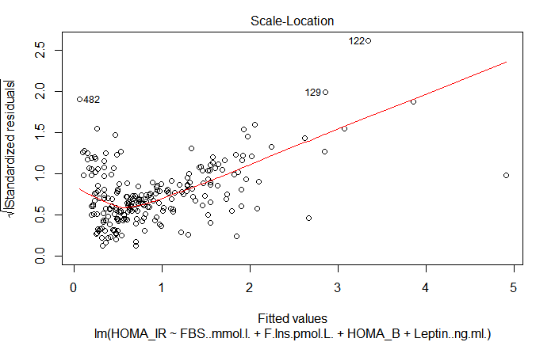

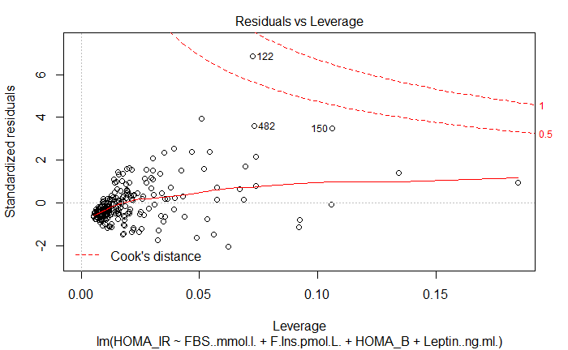

```r
plot(lmH2)
```

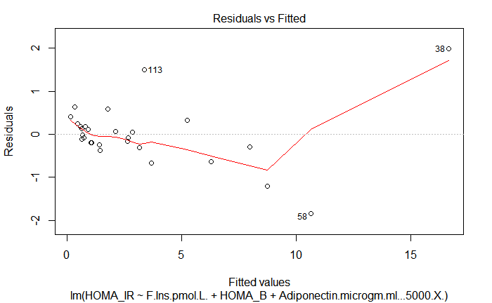

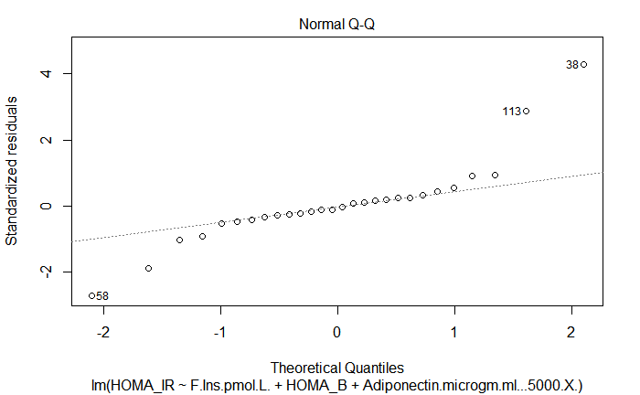

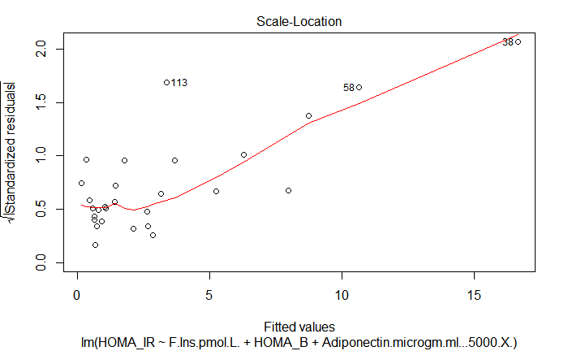

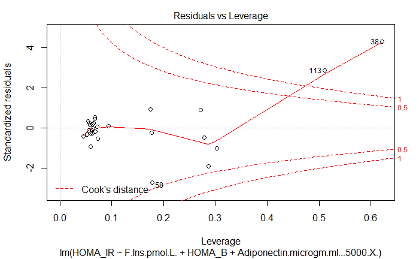

```r
plot(lmDM2)
```

```r
shapiro.test(residuals(lmH2))
```

```
    Shapiro-Wilk normality test

data:  residuals(lmH2)
W = 0.84167, p-value = 2.067e-14
```

```r
shapiro.test(residuals(lmDM2))
```

```
    Shapiro-Wilk normality test

data:  residuals(lmDM2)
W = 0.90718, p-value = 0.01692
```

```r
ncvTest(lmH2)
```

```
Non-constant Variance Score Test
Variance formula: ~ fitted.values
Chisquare = 185.5233, Df = 1, p = < 2.22e-16
```

```r
ncvTest(lmDM2)
```

```
Non-constant Variance Score Test
Variance formula: ~ fitted.values
Chisquare = 40.16637, Df = 1, p = 2.3323e-10
```

```r
bptest(lmH2)
```

```
    studentized Breusch-Pagan test

data:  lmH2
BP = 34.782, df = 4, p-value = 5.149e-07
```

```r
bptest(lmDM2)
```

```
    studentized Breusch-Pagan test

data:  lmDM2
BP = 19.236, df = 3, p-value = 0.0002443
```

De nuevo obtenemos resultados de no-normalidad y heterocedasticidad en los residuos.Podría ser útil plantearnos una transformación de los datos, o utilizar un test no parmétrico, como el test de Kruskal-Wallis.

**Representación del plano de regresión.** Por último, dado un modelo con dos predictores continuos,se puede representar el plano de regresión. Como ejemplo utilizaremos la glucemia e insulinemia como predictores de la IR:

```r
modelo<- lm(HOMA_IR~FBS+Ins, data = datosdf2)
rango_fbs <- range(datosdf2$FBS)
nuevos_valores_fbs <- seq(from = rango_fbs[1], to = rango_fbs[2],
                            length.out = 200)
rango_ins <- range(datosdf2$Ins)
nuevos_valores_ins <- seq(from = rango_ins[1], to = rango_ins[2],
                          length.out = 200)

predicciones <- outer(X = nuevos_valores_fbs, Y = nuevos_valores_ins,
                      FUN = function(FBS,Ins) {
                          predict(object = modelo,
                                  newdata = data.frame(FBS,Ins))
                          })

superficie <- persp(x = nuevos_valores_fbs, y = nuevos_valores_ins,
                    z = predicciones,
                    theta = 40, phi = 10,
                    col = "lightblue", shade = 0.5,
                    zlim = range(-40,300),
                    xlab = "FBS", ylab = "INS", zlab = "IR",
                    ticktype = "detailed",
                    main = "IR media ~ FBS Y INS"
                  )

observaciones <- trans3d(datosdf2$FBS, datosdf2$Ins, datosdf2$HOMA_IR, superficie)
error <- trans3d(datosdf2$FBS, datosdf2$Ins, fitted(modelo), superficie)
points(observaciones, col = "red", pch = 16)
```

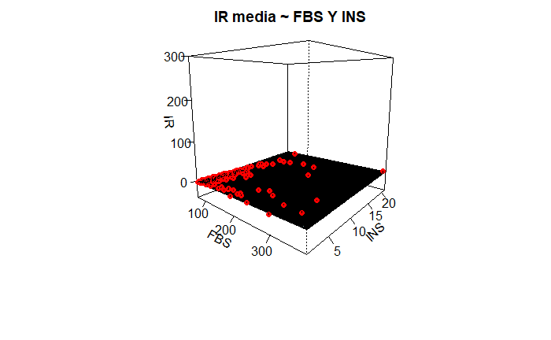

```r
segments(observaciones$x, observaciones$y, error$x, error$y)
```

**(8) Conclusiones.**

1. El IMC sigue una relación lineal positiva con el perímetro de la cintura.
2. El IMC no parece influir directamente en ser resistente a la insulina. Hemos visto que no hay diferencias significativas entre los grupos obeso/no obeso en general, pero podríamos analizar también si existen diferencias entre obesos y no dentro de cada grupo DM2 no-DM2. En cambio sí que la resistencia a la insulina difiere entre diabéticos o no diabéticos.
3. Los parámetros que más influyen en ser resistente son: para ambos grupos, niveles de insulina en sangre en ayunas y la función de las células beta (de manera negativa, como era de esperar). Observamos que los niveles de leptina son más significativos en el caso de los individuos sanos, en cambio en el caso de los diabéticos es más significativa la adiponectina, ambos de manera negativa también. Los niveles de azúcar en ayunas, aunque explican algo de variabilidad, no son tan significativos en el caso de los diabéticos, pero sí en el grupo de individuos sanos.
4. Sería necesario estudiar otras variables como podrían ser algunos factores externos: la ingesta de glucosa diaria, el índice glucémico o insulínico de los alimentos en la dieta, tipo de actividad física realizada. Así como parámetros metabólicos, por ejemplo la hemoglobina glicosilada (HbA1c), un parámetro que mide el grado de glicosidación que sufre la molécula de hemoglobina durante la vida del hematíe (unos 180 días) y que por tanto, constituye un promedio de la concentración de glucosa en sangre que el individuo ha mantenido durante ese tiempo, reflejando mejor la glucemia que la medida puntual de una concentración de glucose en ayunas.

Otras cuestiones que nos podríamos haber planteado son:

1. ¿Existe relación entre los niveles de insulina en plasma y alguno de los parámetros de adiposidad?
2. Como hemos mencionado, sería necesario dividir la muestra entre grupos obesos-no obesos y analizar de nuevo las diferencias entre diabéticos o no diabéticos de algunos de los parámetros metabólicos(insulina, IR, leptina,…).